# Text mining met R

Jeroen Claes

11/4/2021

## Text mining met R

Welkom op het video kanaal van CROPLAND. Mijn naam is Jeroen Claes en ik ben een data scientist bij CROPLAND. In een eerdere aflevering heb ik getoond hoe je eenvoudig teksten van internet-websites kan afhalen. In dit filmpje ga ik je tonen hoe je aan de hand van text-mining technieken kan berekenen en visualiseren hoe gelijkend de inhoud van de voorpagina’s van De Morgen, De Standaard, Het Belang Van Limburg, VRTNWS, en De Gazet Van Antwerpen zijn.

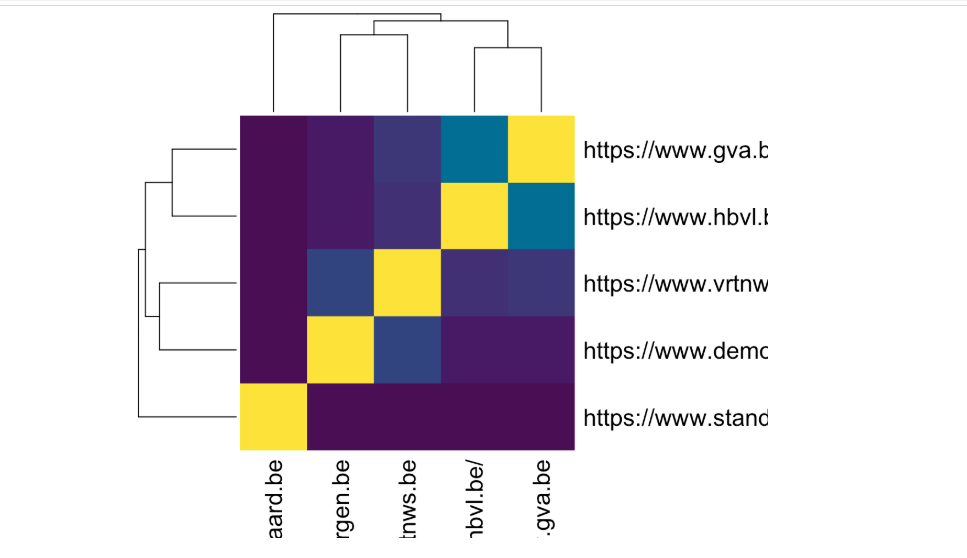

## Packages

Laten we beginnen met een aantal packages te laden. Om aan text mining te doen gebruiken we hier het tidytext pakket. Dit pakket laat het toe om met standaard data-manipulatie tools zoals dplyr aan textmining te gaan doen.Als laatste laden we ook het stopwords pakket. Dit pakket bevat lijsten van vaak voorkomende woorden, die we niet willen meenemen in onze analyse

```r
library(tidytext)
library(stopwords)
```

## Data

De data die we gebruiken in deze video hebben in een eerdere aflevering afgehaald. De data bevat twee kolommen: url en text. In de URL kolom houden we bij welke nieuwssite welke tekst heeft geleverd. Met de functie glimpse van het pakket dplyr kunnen we snel even kijken hoe de data er ook alweer uitziet.

```r
glimpse(resultaten)
```

```
## Rows: 2,088
## Columns: 2
## $ url  <chr> "https://www.demorgen.be", "https://www.demorgen.be", "https://ww…
## $ text <chr> "Men mikt verschrikt, ten einde raad,en veel te weinig én te laat…
```

## Text mining

Een eerste stap die we gaan uitvoeren is het splitsen van de teksten in woorden. Dit kunnen we eenvoudig doen met de functie unnest_tokens van het tidytext package. Op deze manier verkrijgen we een langere tabel waarin ieder woord op zijn eigen rij staat. Deze functie neemt drie argumenten: een data.frame met daarin de data, input, de naam van de input kolom, output, de naam van de kolom waarin de individuele woorden in terecht moeten komen, en token, de eenheid waarin gesplitst moet worden. We kiezen hier voor om de kolom text te splitsen in words en de output weg te schrijven naar de kolom “word”.

```r
resultaten <- resultaten %>%
  unnest_tokens(input=text, output="word", token="words")

glimpse(resultaten)
```

```
## Rows: 15,260
## Columns: 2
## $ url  <chr> "https://www.demorgen.be", "https://www.demorgen.be", "https://ww…
## $ word <chr> "men", "mikt", "verschrikt", "ten", "einde", "raad", "en", "veel"…
```

Nu we de data in dit handige formaat hebben kunnen we een aantal textmining taken eenvoudig uitvoeren. Een van die taken is het verwijderen van stopwoorden, of vaak voorkomende woorden. Met het stopwords pakket kunnen we eenvoudig een lijst ophalen van deze soort woorden.

```r
stopwords("nl")
```

```
##   [1] "de"      "en"      "van"     "ik"      "te"      "dat"     "die"
##   [8] "in"      "een"     "hij"     "het"     "niet"    "zijn"    "is"
##  [15] "was"     "op"      "aan"     "met"     "als"     "voor"    "had"
##  [22] "er"      "maar"    "om"      "hem"     "dan"     "zou"     "of"
##  [29] "wat"     "mijn"    "men"     "dit"     "zo"      "door"    "over"
##  [36] "ze"      "zich"    "bij"     "ook"     "tot"     "je"      "mij"
##  [43] "uit"     "der"     "daar"    "haar"    "naar"    "heb"     "hoe"
##  [50] "heeft"   "hebben"  "deze"    "u"       "want"    "nog"     "zal"
##  [57] "me"      "zij"     "nu"      "ge"      "geen"    "omdat"   "iets"
##  [64] "worden"  "toch"    "al"      "waren"   "veel"    "meer"    "doen"
##  [71] "toen"    "moet"    "ben"     "zonder"  "kan"     "hun"     "dus"
##  [78] "alles"   "onder"   "ja"      "eens"    "hier"    "wie"     "werd"
##  [85] "altijd"  "doch"    "wordt"   "wezen"   "kunnen"  "ons"     "zelf"
##  [92] "tegen"   "na"      "reeds"   "wil"     "kon"     "niets"   "uw"
##  [99] "iemand"  "geweest" "andere"
```

Eens we weten welke woorden we willen verwijderen, kunnen we de woorden uitfilteren met de dplyr functie filter

```r
resultaten <- resultaten %>%
  filter(!word %in% stopwords("nl"))
```

We willen enkel woorden overhouden, dus we gooien ook alle getallen weg. Dit kan met een reguliere expressie, de base functie grepl, en de dplyr functie filter

```r
resultaten <- resultaten %>%
  filter(!grepl("[[:digit:]+]", word, perl=TRUE))
```

Op dit moment bevat onze data enkel nog de woorden die mogelijks relevant zijn voor onze analyse. Door de dplyr functies group_by toe te passen op de kolom url en word kunnen we nu tellen hoe vaak een bepaald woord voorkomt binnen een bepaalde website. Dit doen we met de dplyr functie tally

```r
resultaten <- resultaten %>%
  group_by(url, word) %>%
  tally()
```

Met de tellingen van deze woorden kunnen we nu berekenen hoe gelijkend de voorpagina’s van de verschillende nieuwsmedia zijn. Dit doen we door de data eerst om te zetten met `cast_sparse` naar een grote tabel waarin elke website een rij vormt en alle woorden in die websites een kolom. Met deze matrix kunnen we vervolgens de afstand tussen de verschillende nieuwsmedia berekenen met de dist() functie.

```r
distance <-resultaten %>%
  cast_sparse(url, word, n) %>%
  as.matrix() %>%
  dist() %>%
  as.matrix()

distance
```

```
##                          https://www.demorgen.be https://www.gva.be
## https://www.demorgen.be                   0.0000           169.4698
## https://www.gva.be                      169.4698             0.0000
## https://www.hbvl.be/                    169.6054            66.9328
## https://www.standaard.be                195.8418           125.3395
## https://www.vrtnws.be                   187.1042           124.0161
##                          https://www.hbvl.be/ https://www.standaard.be
## https://www.demorgen.be              169.6054                 195.8418
## https://www.gva.be                    66.9328                 125.3395
## https://www.hbvl.be/                   0.0000                 127.8828
## https://www.standaard.be             127.8828                   0.0000
## https://www.vrtnws.be                126.9252                 159.7811
##                          https://www.vrtnws.be
## https://www.demorgen.be               187.1042
## https://www.gva.be                    124.0161
## https://www.hbvl.be/                  126.9252
## https://www.standaard.be              159.7811
## https://www.vrtnws.be                   0.0000
```

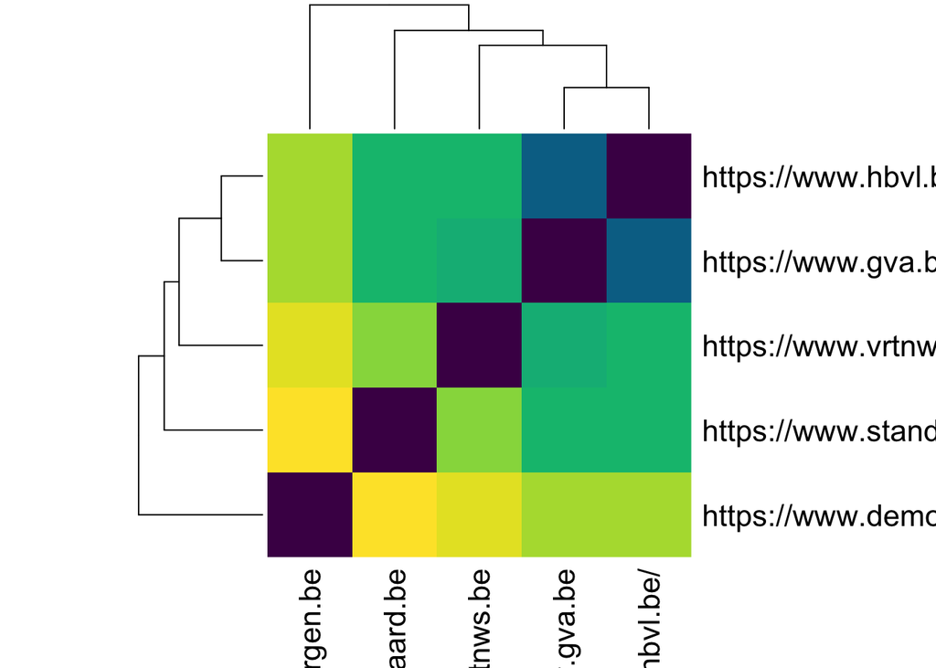

```r
distance %>%
  heatmap(scale = "none", col=hcl.colors(25))
```